# 第13回 誤解を招くグラフ・回帰分析の報告・全体の振り返り

経済データ入門

第13回

誤解を招くグラフ・回帰分析の  
報告・全体の振り返り

同じデータから、正反対の主張が作れてしまう

経済データ入門

第13回 — Topic01

誤解を招くグラフ

数字を変えずに、印象を変える

## 前回の振り返り

前回のポイント 第12回「重回帰・欠落変数バイアス・補正 R2・F 検定」

Q: 回帰分析の出力表から、何を読んだか

- **係数**：ほかの説明変数をそろえたときの差
- **補正 R2**：関係の無い変数でも R² は上がる。その分を差し引いて比べる
- **有意 F**：入れた変数を全部まとめて、偶然だけで説明できるか

出力表は読めるようになった。最後は、それを人に渡す番  
渡すときは、グラフの見せ方でも印象が変わる

## この回の道のりと「サンプル」シート

1

誤解を招くグラフ

演習 13-1

家計の折れ線

2

回帰分析の報告

演習 13-2・13-3

家計の報告

3

全体の振り返り

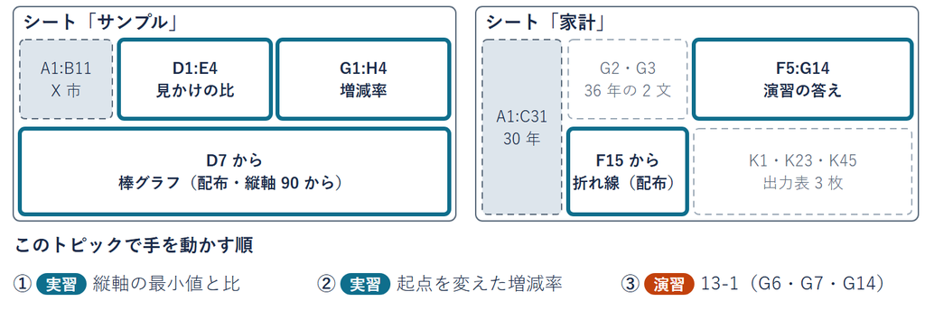

置き場は lec13-exercise.xlsx の 2 つのシート。誇張グラフも入っている

## グラフの描き方

数字が正しければ、グラフも正しいか

- **いまの道具**：表をグラフにできる。出力表も読める
- **足りない所**：ニュースで「観光客が急増」のグラフを見ても、  
  軸と期間は描いた人が決めている
- **困ること**：小さな増えを「急増」と受け取ると、判断を誤る
- **知りたいこと**：数字を 1 つも変えずに、印象だけを変えられるか
- **そこで**：X 市の 2 本の棒で、縦軸だけを動かしてみる

## X 市の 2 本の棒

[figure not shown]

観光課の担当者として、2024 年 92 万人と 2025 年 96 万人を比べる  
縦軸は 0 から（いちばん下の目盛りが 0）。2 本はほぼ同じ高さ  
サンプルデータ（架空）。lec13-exercise.xlsx の「サンプル」A1:B11

## たしかめ 縦軸の最小値 90

縦軸の最小値（いちばん下の目盛り）を 90 にすると  
2 本の棒は何倍の差に見えるか

**1**  
約 1.04 倍

**2**  
約 1.5 倍

**3**  
約 3.0 倍

90 にすると、2 本とも 90 より下が切り落とされる  
1 つ決めてから先へ。答えは次のページで

## 縦軸の最小値と棒の見え方

[figure not shown]

「見える」は、最小値から上に見えている棒の高さ

数字は 1 つも変えていない。変えたのは軸だけ。たしかめの答えは 3 番

## 見かけの比

式

$$\text{見かけの比} = (96 - \text{最小値}) \div (92 - \text{最小値})$$

見かけの比＝目に見える 2 本の棒の長さの比  
96 は 2025 年、92 は 2024 年。棒の見える部分は、最小値から上だけ

最小値 90

$(96 - 90) \div (92 - 90)$

$= 6 \div 2 = 3.0$

見かけ 3.0 倍

最小値 80

$(96 - 80) \div (92 - 80)$

$= 16 \div 12 \approx 1.33$

見かけ 1.33 倍

最小値 0

$(96 - 0) \div (92 - 0)$

$= 96 \div 92 \approx 1.04$

実際の比と同じ

最小値 0 のときだけ、見かけの比が実際の比 1.04 倍と同じ

## 縦軸の最小値と見かけの比

1. **開く**：D7 の棒グラフの  
   縦軸の数字をダブルクリック
2. **変える**：「最小値」の欄  
   （いまは 90）を  
   80 → 0 に打ち替えて Enter
3. **記録**：E2 に  
   `=(B$11-D2)/(B$10-D2)`  
   E4 までオートフィル  
   （行の前の印で 96・92 を固定）

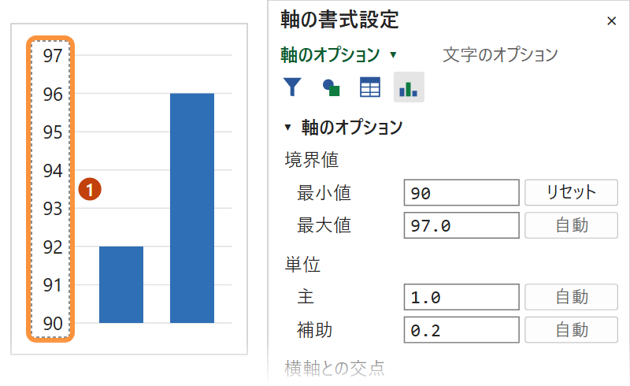

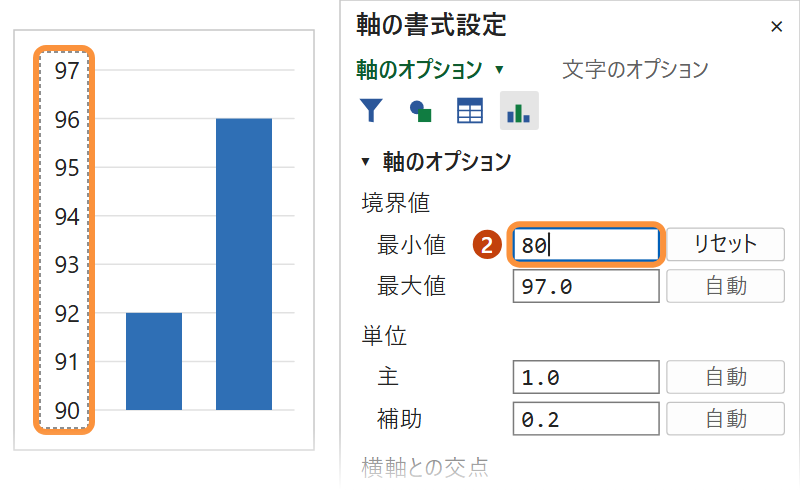

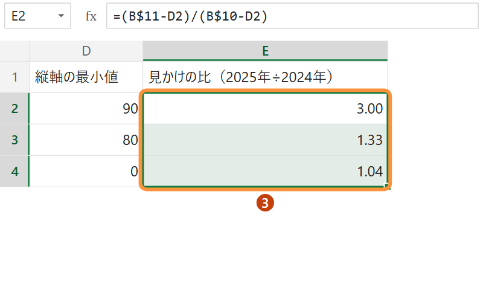

Mac も縦軸をダブルクリックで「軸の書式設定」が開く

✋ 動画を止めて ①〜③ を進め、E2〜E4 が出たら再生に戻る

## 誤解を招くグラフ

**誤解を招くグラフ：数字はそのまま、軸と期間で印象を変えたグラフ**

用語

**縦軸の切り詰め**軸の下を切り、小さな差を大きく見せる

計算は正しい。正しい計算から、誤った印象が生まれる  
帯の「期間」のほうは、次のページで見る

## X 市の 10 年の折れ線

[figure not shown]

前の 2 本は、この 10 年の折れ線の最後の 2 年。起点＝どの年と比べるか  
増減率 ＝（2025 年の人数 − 起点の年の人数）÷ 起点の年の人数  
10 年間なら −20.0%（2 割減）、2022 年からなら +23.1%、前年比なら +4.3%  
**期間の切り取り**：起点を選び、増減の印象を変える

## 起点を変えた増減率

1. **10 年間**：2016 年は B2・2022 年  
   は B8・2024 年は B10  
   H2 に `=(B11-B2)/B2` → −20.0%
2. **2022 年から**：H3 に  
   `=(B11-B8)/B8` → 23.1%
3. **前年比**：H4 に  
   `=(B11-B10)/B10` → 4.3%

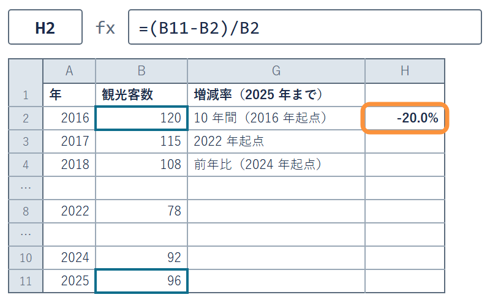

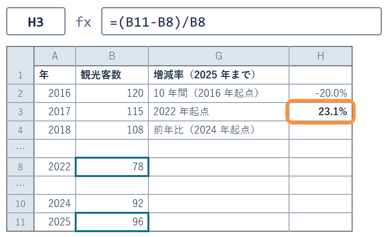

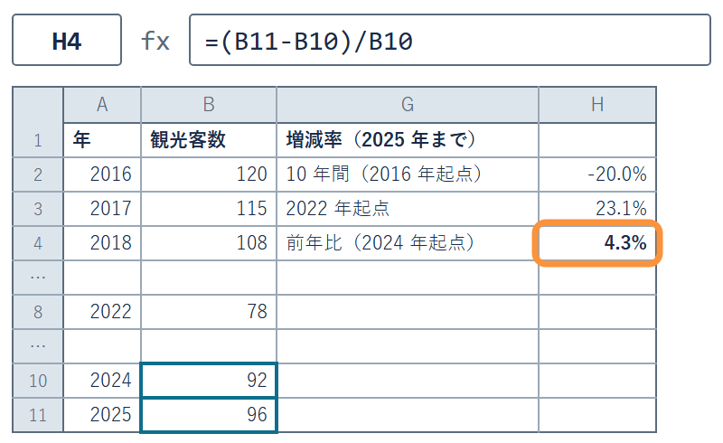

B8 が 2022 年。H 列は % 表示にしてある（小数第 1 位）

✋ 動画を止めて ①〜③ を進め、3 つの増減率が出たら再生に戻る

## 3D 円グラフ

[figure not shown]

4 つとも同じ 25%。立体にすると、手前の扇形が大きく見える  
困ること：手前がいちばん多いと読んでしまう  
直し方：3D を選ばず、平面の円グラフか棒グラフにする

## 二重軸（左右に別々の縦軸）

[figure not shown]

内閣府「国民経済計算」の家計の消費と正味資産（資産 − 借金）  
困ること：左右の目盛りの範囲しだいで、交差にも連動にも見える  
直し方：1994 年 ＝ 100 の指数で 1 本の軸に（2023 年は 120.8 と 121.5）

## 階級の幅

[figure not shown]

階級の幅＝1 本の棒がまとめる範囲。  
同じ 30 人の通学時間（サンプルデータ）  
平均 44.1 分の 40 分台は 2 人だけ。平均の人はほとんどいない  
直し方：幅を何通りか試し、選んだ幅を書く

## 家計の最終消費支出

- **統計**：内閣府「国民経済計算」の年次推計（2015 年基準）
- **最終消費支出**：家計が 1 年にモノやサービスに使ったお金
- **単位**：兆円・暦年  
  （1 月〜12 月の年）・1994〜2023 年の 30 年（2026-09-22 取得）
- **列**：A が年、B が消費、C が可処分所得（次のトピックで使う）

**実データ**：lec13-exercise.xlsx「家計」の A1:C31

## 家計の消費 30 年の 2 枚

[figure not shown]

軸：260 から切ると急に伸びて見え、0 からだとほぼ平ら  
30 年の実際は 263.8 → 318.8 兆円で +20.8%（1.21 倍）  
期間：外出控えの 2020 年（282.6 兆円）から数えると、3 年で +12.8%

## 見せ方の決まり

決まり

1棒グラフの縦軸は 0 から。折れ線で切るなら注記

2期間は全体から見せ、そのあとで一部の期間を語る

3図のすぐ下に出典を 1 行

棒は長さで量を見せるので、0 から描くと決めてある（作法）  
切る側の言い分は「差を見やすくしたい」。だから切るなら注記  
ニュースのグラフも、軸と期間をまず確かめる

## 演習 13-1 家計の折れ線と増減率

演習 13-1

家計の折れ線を直し、起点の違う増減率を 2 つ出す

1. **直す**：「家計」の F15 の折れ線（縦軸 260 から）の縦軸をダブルクリックし、  
   最小値を 0 に。直した最小値を G14 に数で
2. **1994 年起点**：G6 に 2023 年までの増減率を式で（1994 年は 2 行目・2023 年は 31 行目）
3. **2020 年起点**：G7 に 2023 年までの増減率を式で（2020 年は 28 行目）
4. **答え**：G6・G7・G14 の値が提出の答え  
   （G6・G7 は % 表示にしてある）。式の形は実習の H 列と同じ

✋ 動画を止めて演習 13-1 を進め、終わったら再生に戻る

## 家計の 2 つの増減率

1994 年起点

$(318.8 - 263.8) \div 263.8$

$\approx 0.208$

+20.8%（30 年）

2020 年起点

$(318.8 - 282.6) \div 282.6$

$\approx 0.128$

+12.8%（3 年）

演習 13-1 の答え（G6・G7・G14）

G14：直した縦軸の最小値は 0

式は `=(B31-B2)/B2` と `=(B31-B28)/B28`

30 年で 2 割増（+20.8%）、直近 3 年だけでも 1 割増（+12.8%）  
どちらを見せるかで「ゆるやか」にも「急増」にもできる

## Q&A 誤解を招くグラフ

Q1 最小値を 0 にしたのに、また切れている

欄が「自動」に戻った。最小値の欄に **0 を打って Enter** で固定する

Q2 E3 は −5.00 に、E4 は #DIV/0! になった

92 と 96 の行を固定し忘れ。`B$11`・`B$10` のように行番号の前に付ける（D2 は付けない）

Q3 H3 が 11.6% になった

起点が 2023 年（B9）になっている。2022 年は **B8**

## まとめ

- **誤解を招くグラフ**：数字はそのまま、軸と期間で印象を変えたグラフ
- **縦軸の切り詰め**：最小値 90 で、1.04 倍が 3.0 倍に
- **期間の切り取り**：起点で −20.0% にも +23.1% にも
- **決まり**：軸を切るなら注記・期間は全体から・図には出典

見せ方で印象は変えられた。同じことが、P-値のような判定でも起きるか  
これを次のトピックで見る

経済データ入門

第13回 — Topic02

回帰分析の報告

同じデータで、判定はひっくり返る

## この回の道のりと「家計」シート

1

誤解を招くグラフ

演習 13-1

家計の折れ線

2

回帰分析の報告

演習 13-2・13-3

家計の報告

3

全体の振り返り

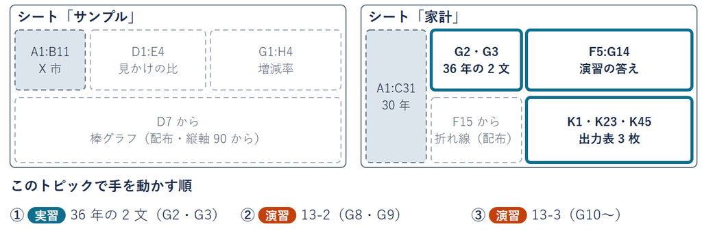

置き場は「家計」の G2・G3（実習）と F5:G14（演習の答え）

## 出力表の係数の行

[figure not shown]

前に出てきた 5 人の出力表（サンプルデータ・バイト日数と自習時間）  
② 標準誤差：データを取り直したときの、係数の散らばりの幅  
③ t：係数 ÷ 標準誤差（0 から、標準誤差の何個分離れているか）

## P-値と 95% 区間を思い出す

**P-値**本当の係数が 0 でも、手元の t と同じか  
それより 0 から離れた t が偶然出る割合

**95% 区間**同じ調べ方をくり返すと  
本当の係数を 100 回に約 95 回含む幅

5 人の P = 0.041：本当の係数が 0 の世界で 100 回取り直すと  
約 4 回は t が ±3.46 の外に出る  
区間 [−3.84, −0.16] は 0 を含まない  
だから「関係なし」とは区別できる

## 出力表の渡し方

読めた出力表を、人にどう渡すか

- **いまの道具**：係数・標準誤差・P-値・95% 区間を読める
- **足りない所**：ゼミの発表やレポートに出力表を  
  丸ごと貼ると、数が 31 個並ぶ  
  読み手は −2.0 と 0.041 を自分で探すことになる
- **もう 1 つ**：「有意でした」だけでは、どれくらいの大きさかが消える
- **そこで**：同じ行の数を、決まった順に 1 文に並べる

## 報告の部品と出力表の列

[figure not shown]

部品は全部、バイト日数の行にある。同じ番号どうしが対応する  
P-値 0.0405 は小数第 3 位で 0.041  
t は書かない（係数 ÷ 標準誤差で、P と同じことを別の目盛りで言う）

## 回帰分析の報告

回帰分析の報告：係数の大きさと、  
偶然で説明できるかを、一組にして書く

定義

［変数名］の係数は $a$（標準誤差 $s$、95%区間 $[l, u]$、P = $p$）

＋ 言葉の 1 文（係数を単位つきで読む）

大きさ＝係数、偶然で説明できるか＝P-値と 95% 区間

**今回は**：バイト日数の係数は −2.0  
（標準誤差 0.58、95%区間 [−3.84, −0.16]、P = 0.041）  
バイトが 1 日多い人は、自習が約 2 時間短い

## 報告の書き方の決まり

決まり

1係数（大きさ）を先に、P を後に

2直後に言葉の 1 文。係数を単位つきで読む

395%区間と P は落とさない

読み手がまず知りたいのは「どれくらい変わるか」  
区間を落とすと「かろうじて」と「はっきり」  
の区別が消える（家計で見る）

## 36 年の出力表

[figure not shown]

**実データ**：前に出てきた総務省統計局の 36 年（1991〜2026 年）  
完全失業率（労働力調査）と物価上昇率（消費者物価指数）の年平均  
2026 年は 1〜5 月の平均。出力表はブックに無いので、この図を使う  
P-値 2.91478E-07 は、小数点を左へ 7 つ動かした 0.000000291…

## 36 年の型の 1 文

1. **読む**：完全失業率の行の 5 つ  
   係数 −0.8588・標準誤差 0.135  
   P-値 2.91478E-07  
   下限 −1.1331・上限 −0.5846
2. **型**：「家計」の G2 に型の 1 文  
   （F2 の書き出しどおり）  
   数は小数第 3 位まで・とても  
   小さい P は P < 0.001
3. **言葉**：G3 に言葉の 1 文  
   割合どうしの差は「ポイント」

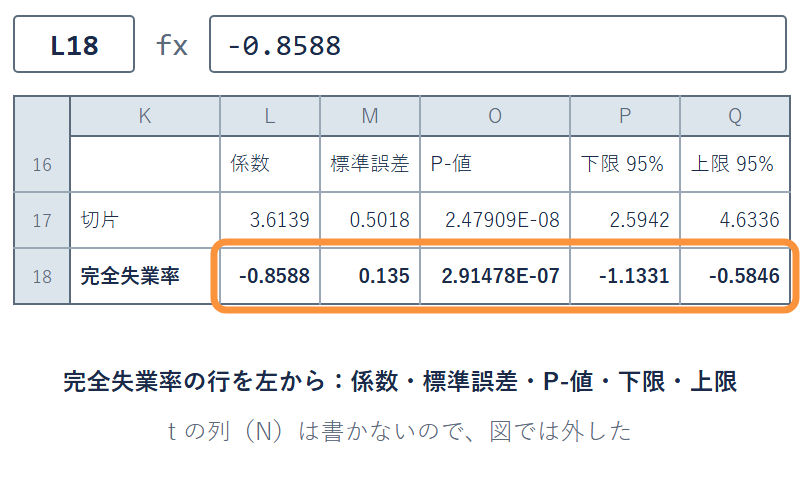

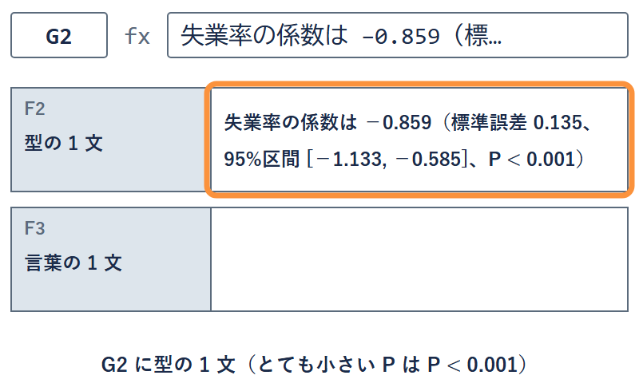

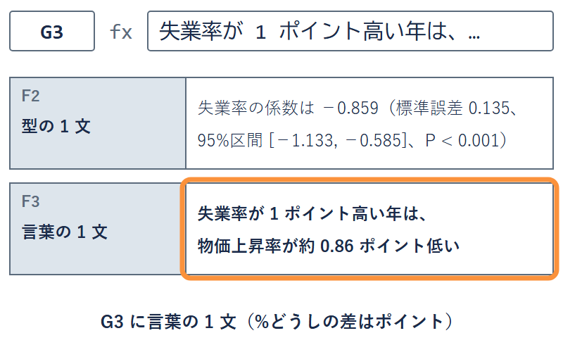

✋ 動画を止めて ①〜③ を進め、G2・G3 を打てたら再生に戻る

## 36 年の報告の 2 文

答え

**型**失業率の係数は −0.859（標準誤差 0.135  
95%区間 [−1.133, −0.585]、P = 2.9 × 10⁻⁷）

**言葉**失業率が 1 ポイント高い年は  
物価上昇率が約 0.86 ポイント低い

%で測った 2 つの量の差は「ポイント」。  
「約 0.86% 低い」と書くと別の意味になる  
セルには P < 0.001 と打ってよい  
（それより細かい桁は判定を変えない）

## よくある失敗 P の読み

**取り違え**  
P = 0.041 なので  
係数が 0 である確率は 4%

**正しい読み**  
係数が 0 の世界で、これ以上  
0 から離れた t が偶然出る  
割合が 0.041

**取り違え**  
P = 0.07 なので、ほぼ有意

**正しい読み**  
0.05 を超えた  
偶然と区別できなかった

0.05 は、多くの分野で前もって決めておく目安  
超えたか超えないかで、そのまま書く

## 4 つの 95% 区間

[figure not shown]

下の 2 本は、同じ 36 年の表から 9 年と 7 年だけを取り出して回し直した区間  
0 が区間の外 ＝ P が 0.05 以下（前に出てきた、区間と検定の表裏）  
2013〜2019 年の区間 [−1.035, 0.810] だけが 0 をまたぐ

## よくある失敗 区別できない P

**取り違え**  
2013〜2019 年は P = 0.767  
だから失業率と物価は無関係

**正しい読み**  
この 7 年では、傾きを  
偶然と区別できなかった

区間は −1 くらいかもしれないし、+0.8 くらいかもしれない  
絞り込めなかっただけで、無関係を示したわけではない  
0 と区別できない＝偶然と区別できない（以下この言い方で）

## よくある失敗 P と大きさと原因

**取り違え**  
P が小さいので、効果が大きい

**正しい読み**  
大きさは係数と単位で読む

**取り違え**  
P が小さいので  
原因だと証明された

**正しい読み**  
関連が見られる  
原因かどうかは別の問い

前に出てきた相関と因果：一緒に動くことと、原因であることは別の話  
P が小さい＝「係数が 0 なら、この結果は出にくい」というだけ

## 同じ表の 2 つの期間

[figure not shown]

同じ 36 年の表から、行だけを変えて回し直した  
点が 7 個と少ないと区間が広がり、P は大きくなりやすい  
どちらの期間を選んだかを書かなければ、読み手には分からない

## 期間で変わる判定

| 期間 | 係数 | 95% 区間 | P | 判定 |
| --- | --- | --- | --- | --- |
| 1991〜1999 年 | −1.059 | [−1.645, −0.472] | 0.0037 | 区別できる |
| 2013〜2019 年 | −0.112 | [−1.035, 0.810] | 0.767 | 区別できない |

**対策：先に範囲を決め、試したものは全部書く**

好きな期間で、どちらの主張も作れる。前に出てきた罠と同じ  
互いに独立な検定を 5% で 20 回行えば、  
どれかが偶然有意になる見込みは約 0.64（64%）

先に決める＝結果を見てから選ぶのを防ぐ  
全部書く＝読み手が確かめられるようにする

## 演習 13-2 家計 30 年の報告

演習 13-2

家計の消費を可処分所得で回帰し、型で書く

1. **開く**：データ → データ分析 → 回帰分析
2. **範囲**：Y に B1:B31（消費）、X に C1:C31（所得）・「ラベル」に印・出力先 K1
3. **型**：G8 に型の 1 文（数は小数第 3 位まで）
4. **言葉**：G9 に言葉の 1 文（1 兆円あたり）

✋ 動画を止めて演習 13-2 を進め、提出の答え G8・G9 を打てたら再生に戻る

**実データ**：内閣府「国民経済計算」。可処分所得＝手取り

## 演習 13-3 期間を変えた家計

演習 13-3

10 年の期間 2 つで回し直し、試した範囲を全部書く

1. **2010〜2019 年**：Y に B18:B27・X に C18:C27（ラベルなし）・出力先 K23
2. **2014〜2023 年**：Y に B22:B31・X に C22:C31（ラベルなし）・出力先 K45
3. **P-値**：O40 と O62（P-値の列の「X 値 1」の行）を G10・G11 に（小数第 3 位まで）
4. **文**：G12 に試した範囲を全部書く 1 文  
   （「1994〜2023 年の 30 年で回した。参考に」から）  
   G13 に 2020 年（消費が減り所得が増えた年）という弱い点を 1 行

✋ 動画を止めて演習 13-3 を進め、G10〜G13 を打てたら再生に戻る

## 家計 30 年の報告の 2 文

答え

**型**可処分所得の係数は 0.426（標準誤差 0.204  
95%区間 [0.007, 0.844]、P = 0.046）

**言葉**可処分所得が 1 兆円多い年は、消費が約 0.43 兆円多い

演習 13-2 の答え

下限 0.007 は 0 にほとんど接する  
「有意」とだけ書くと、この「かろうじて」が消える

## 家計の 3 つの判定

| 期間 | 係数 | 95% 区間 | P | 判定 |
| --- | --- | --- | --- | --- |
| 1994〜2023 年 | 0.426 | [0.007, 0.844] | 0.046 | 区別できる |
| 2010〜2019 年 | 1.074 | [0.238, 1.911] | 0.018 | 区別できる |
| 2014〜2023 年 | 0.414 | [−0.232, 1.061] | 0.178 | 区別できない |

演習 13-3 の答え（2014〜2023 年は 2020 年を含む）

**G12**：1994〜2023 年の 30 年で回した  
参考に 2010〜2019 年と 2014〜2023 年でも回したところ  
前者は P = 0.018 で 0 と区別でき  
後者は P = 0.178 で区別できなかった

## 家計の散布図と 2020 年

[figure not shown]

2020 年は消費 −4.7%・可処分所得 +4.4%。判定を変えた年  
この 1 年を除くと、2014〜2023 年の P は 0.178 → 0.0065  
この結果の弱い点（限界）：2020 年は特殊な年で、結果に影響しうる

## Q&A 回帰分析の報告

Q1 P-値が 2.91478E-07 と出た

小数点を左へ 7 つ動かした数。**P < 0.001** と書いてよい

Q2 行の名前が「X 値 1」になった

ラベルなしで回したため。その行が**可処分所得**の行

Q3 下限と上限の列が 2 組ある

**下限 95%・上限 95%** の組を使う  
（出力表の右端の「95.0%」の組は同じ数）

## まとめ

- **回帰分析の報告**：大きさと偶然かどうかを、一組で書く
- **型**：係数は a（標準誤差 s、95%区間 [l, u]、P = p）＋ 言葉の 1 文
- **言い方**：P が大きい＝区別できなかった。原因は言わない
- **期間**：同じ表でも判定はひっくり返る。試したものは全部書く

分かったこと：報告は係数・区間・P を一組で書き、試した期間も全部書く  
まだ残る問い：ここまでの道具は、1 本の階段になるのか  
これを次のトピックで見る

経済データ入門

第13回 — Topic03

全体の振り返り

この科目で、何が言えるようになったか

## この回の道のりと振り返り

1

誤解を招くグラフ

演習 13-1

家計の折れ線

2

回帰分析の報告

演習 13-2・13-3

家計の報告

3

全体の振り返り

このトピックは演習はなく、スライドだけ。ここまでの道具を並べ直す

## 最初の一歩

- **最初**：Excel のセルに数を打ち、合計を出すところから始めた
- **いま**：回帰分析の出力表を読み、誤解なく書ける
- **並べ方**：回の順だと、道具どうしのつながりが見えない  
  だから「これで何が言えるようになったか」で並べ直す
- **見え方**：下の段が、上の段の前提になる 1 本の階段

## 道具の階段

[figure not shown]

回の順ではなく、言えることの順に並べた。  
段の下は、その段を使った主な回  
どの段にも「これで何が言えるようになったか」がある

## 段 1 出所

**確かめられる数字だけが、根拠になる**（第 1 回）

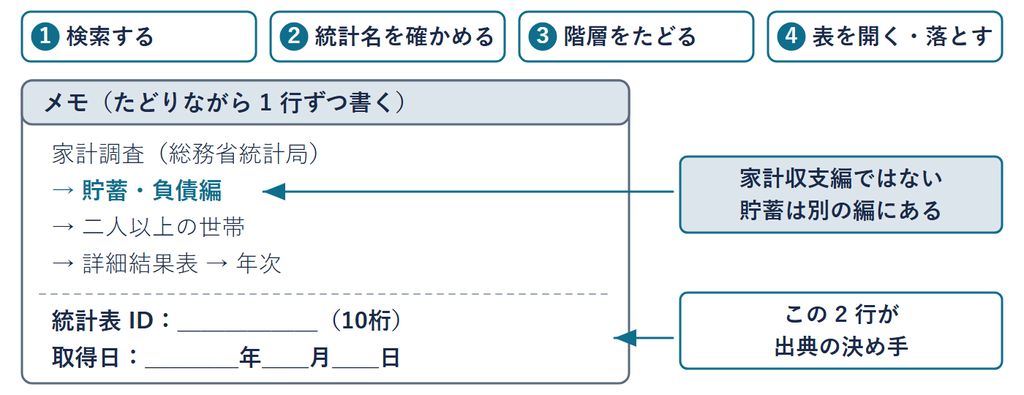

**道具**：一次ソース・出典 4 点セット・データカード

**言えること**：その数を、だれがどう数えたか

第 1〜7 回の最初のトピック。  
民間給与実態統計調査・有価証券報告書・家計調査

## 段 2 表と関数

絶対額では比べられない。相対（比率）にそろえて、  
はじめて比べられる（第 2 回）

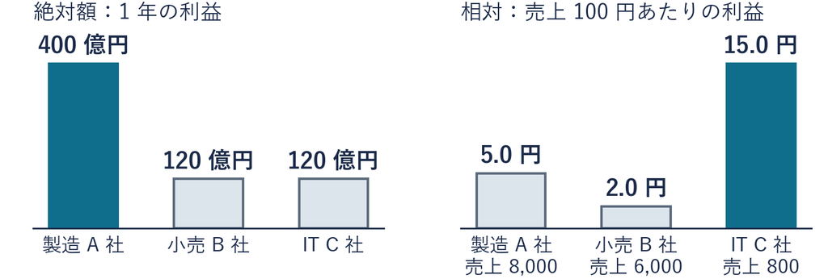

**道具**：テーブル・SUM・AVERAGE・オートフィル・グラフ

**言えること**：表を集計して、1 枚の図にする

前の段で確かめた数を表にし、比率にそろえる。第 1・2 回（財務比率）

## 段 3 参照

**複利の増え方は、利率と時間の両方で決まる**（第 4 回）

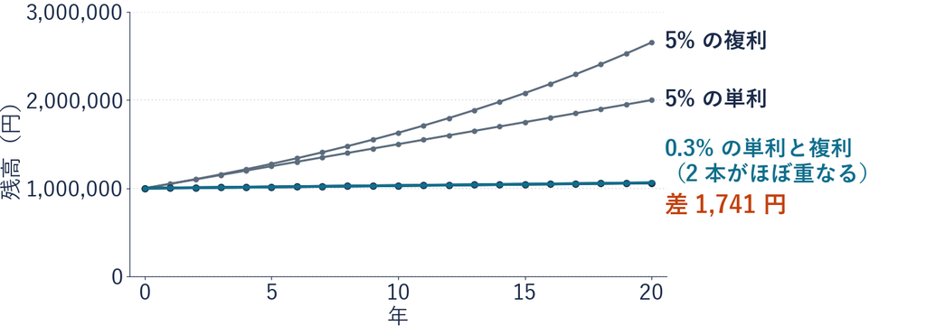

**道具**：`$`・複合参照

**言えること**：前提を 1 か所で変えて、表全体を動かす

前の段の表の、利率と年数を 1 か所のセルに置いて動かす。  
第 4・5 回（金利・物価指数）

## 段 4 整理と集計

**平均を出しただけでは、赤字の 2 世帯は消える**（第 7 回）

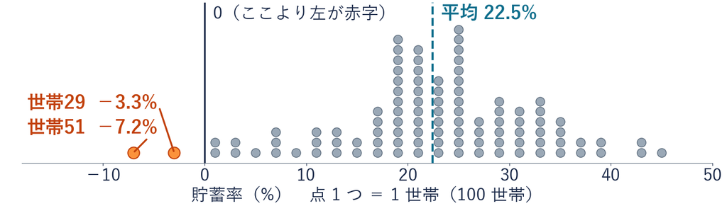

**道具**：Power Query・XLOOKUP・IF・COUNTIF・ピボット

**言えること**：大きな表をつないで、条件で分けて数える

前の段の表をつなぐ。第 6・7 回・県民経済計算・全国家計構造調査

## 段 5 散らばりと相関

**相関係数：単位を消した、2 つの動きの似かた**（第 9 回）

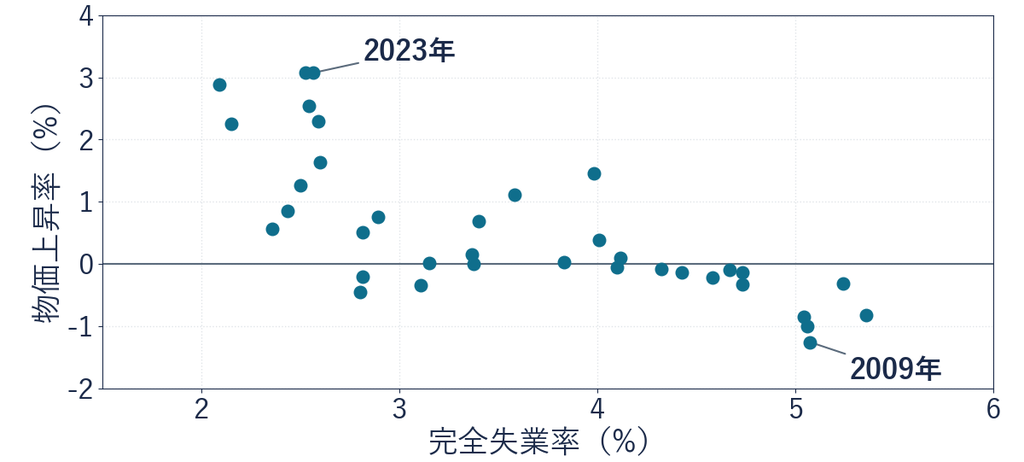

**道具**：平均・中央値・標準偏差・共分散・相関係数

**言えること**：典型と散らばり、2 つの動きの似かた

前の段の表の 2 列を 1 つの数で比べる。r ＝ −0.737。第 3・9 回

## 段 6 回帰の出力表

**単回帰：点の雲を、1 本の線で要約する**（第 10 回）

[figure not shown]

**道具**：最小二乗・P-値・95% 区間（ほかに R²・重回帰）

**言えること**：線で要約し、その線をどこまで信じてよいか

失業率が 1 ポイント高い年は、物価上昇率が約 0.86 ポイント低い  
傾き −0.859。図の +1.67・−1.66 は線からの外れ。第 10〜12 回

## 段 7 人に渡す作法

回帰分析の報告：係数の大きさと、偶然で説明できるかを、  
一組にして書く（第 13 回）

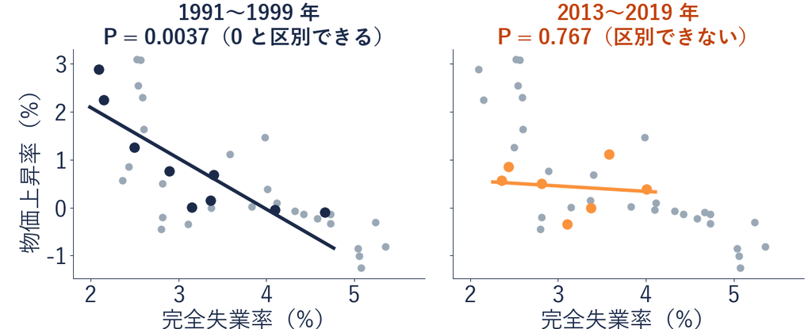

**道具**：誤解を招くグラフ・回帰分析の報告

**言えること**：正しい計算を、誤解なく渡す

1991〜1999 年は傾き −1.06（P = 0.0037）、2013〜2019 年は −0.11（P = 0.767）  
第 13 回（期間で判定が変わる）と第 8 回（主張・根拠・限界の書き方）

## 貫いた確かめの型

型

ある道具で出し、別の道具でもう 1 度出して照合する

**合計と平均**集計行 ↔︎ SUM・AVERAGE（段 2・第 1 回）

**条件で数える**COUNTIF ↔︎ ピボット（段 4・第 7 回）

**傾き**SLOPE ↔︎ 近似曲線 ↔︎ 分析ツール（段 6・第 10 回）

ここまで、複数通りで確かめてきた  
1 通りで出した数は、別の道でもう 1 度出してから人に渡す

## この授業の外で 階段の使い道

- **授業のレポート**：数に出典 4 点セットを付け、  
  表とグラフで示す（段 1・2）
- **ゼミ・卒業論文**：回帰を回したら、型の 1 文と、  
  どの期間のデータで回したかを書く（段 6・7）
- **ニュースのグラフ**：軸の最小値と期間を、まず確かめる（段 7）
- **アルバイト先の売上表**：前の年と比べるなら、  
  起点と単位をそろえる（段 2・3）

どれも、この階段のどこかの段で足りる

## この科目のまとめ

**出所を確かめ、表に整え、関係を数で測り、誤解なく渡す**

- **出所を確かめ**：段 1（その数を、だれがどう数えたか）
- **表に整え**：段 2〜4（集計・参照・つなぐ・数える）
- **関係を数で測り**：段 5・6（相関・回帰の出力表）
- **誤解なく渡す**：段 7（見せ方と語り方の作法）

この先のレポートでも、数はこの 4 つの順で扱う